#Initializing libraries

```r
library("class")
library("e1071")
library("ggplot2")
library("caret")
```

#Attach Data File

```r
epi<- read.csv('Lab3_Assignment2/epi2024results_DA_F24_lab03.csv')
attach(epi)
```

**Question 1** 1. Derive 2 subsets each for a particular region 1.1. Plot histograms for a variable of your choice for both regions with density lines overlay-ed 1.2. Plot QQ plots for both variables compared to known probability distributions.

```r
episub1 <-subset(epi,region=='Southern Asia')
attach(episub1)
print(summary(episub1$EPI))
```

```
##    Min. 1st Qu.  Median    Mean 3rd Qu.    Max.
##   25.50   27.75   31.80   33.08   38.25   43.30
```

```r
print(sd(episub1$EPI))
```

```
## [1] 6.350422
```

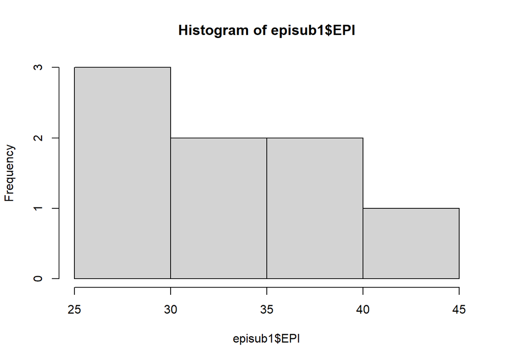

```r
hist(episub1$EPI)
```

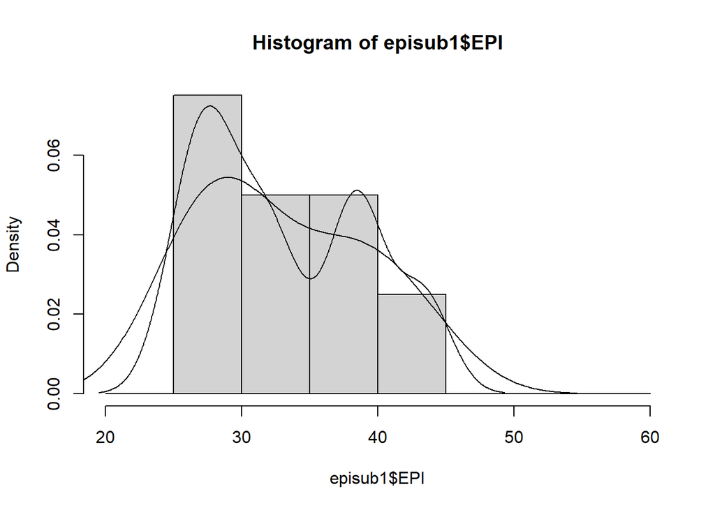

```r
hist(episub1$EPI, seq(20, 60, 5.0), prob=TRUE)
lines(density(episub1$EPI,na.rm=TRUE,bw=2))
lines(density(episub1$EPI,na.rm=TRUE,bw="SJ"))
```

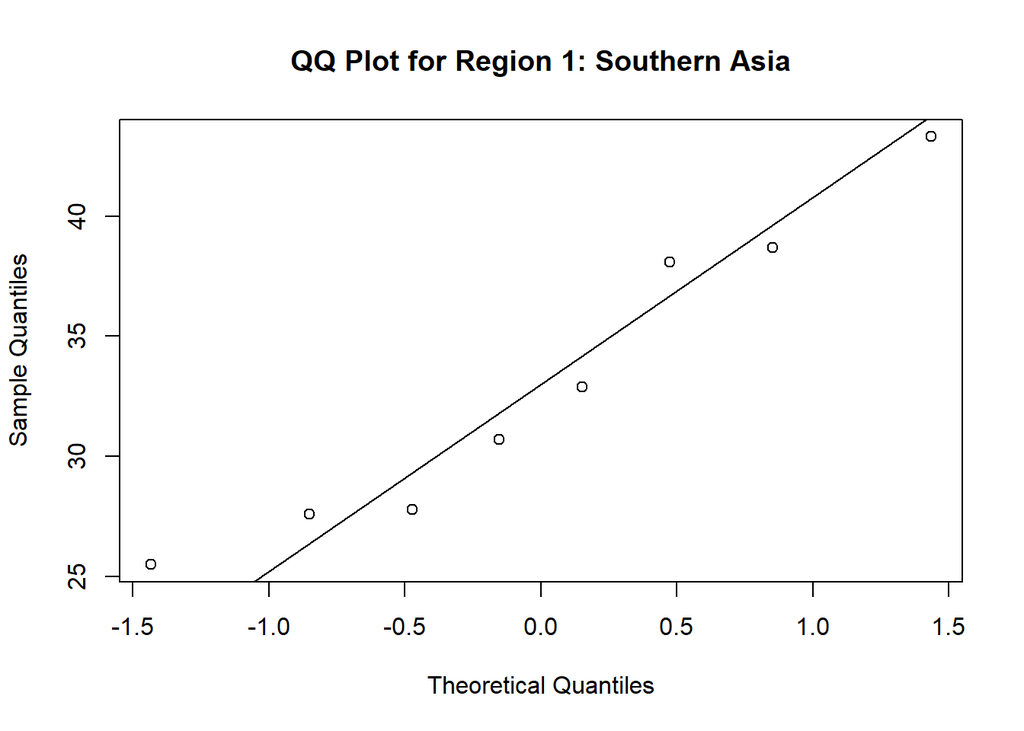

```r
qqnorm(episub1$EPI,main = "QQ Plot for Region 1: Southern Asia")
qqline(episub1$EPI)
```

```r
episub2 <-subset(epi,region=='Latin America & Caribbean')
attach(episub2)
print(summary(episub2$EPI))
```

```
##    Min. 1st Qu.  Median    Mean 3rd Qu.    Max.
##   32.60   45.73   48.90   48.34   52.92   56.60
```

```r
print(sd(episub2$EPI))
```

```
## [1] 5.829893
```

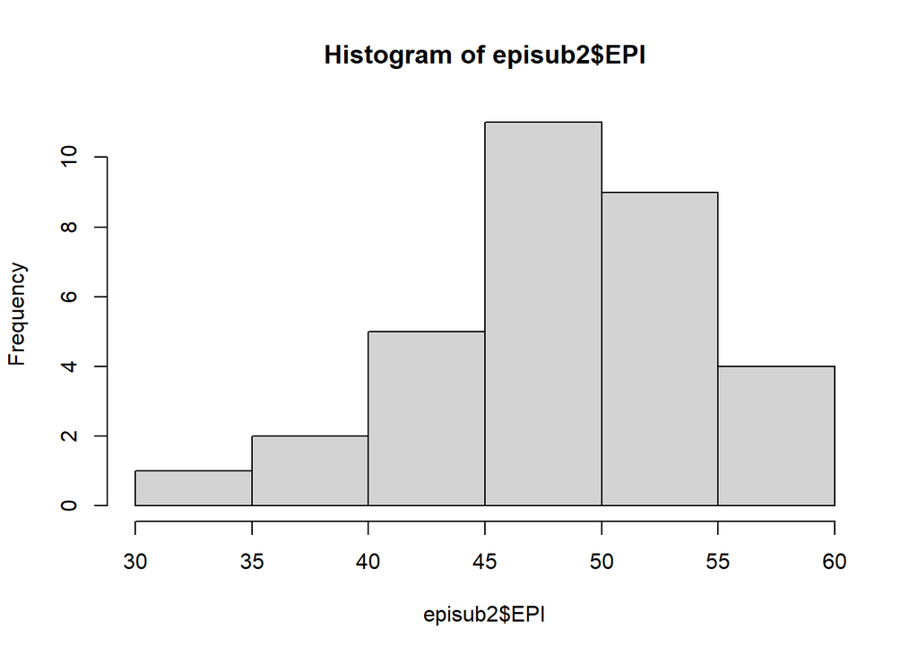

```r
hist(episub2$EPI)
```

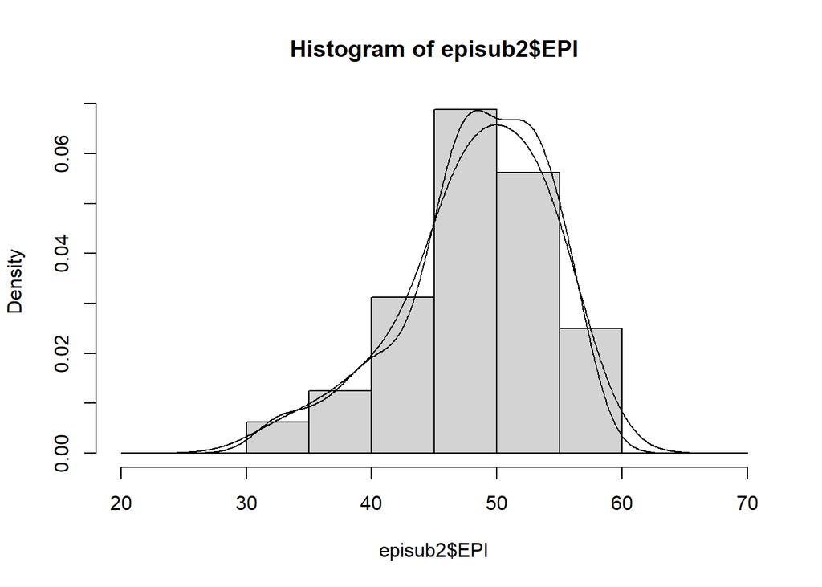

```r
hist(episub2$EPI, seq(20, 70, 5.0), prob=TRUE)
lines(density(episub2$EPI,na.rm=TRUE,bw=2))
lines(density(episub2$EPI,na.rm=TRUE,bw="SJ"))
```

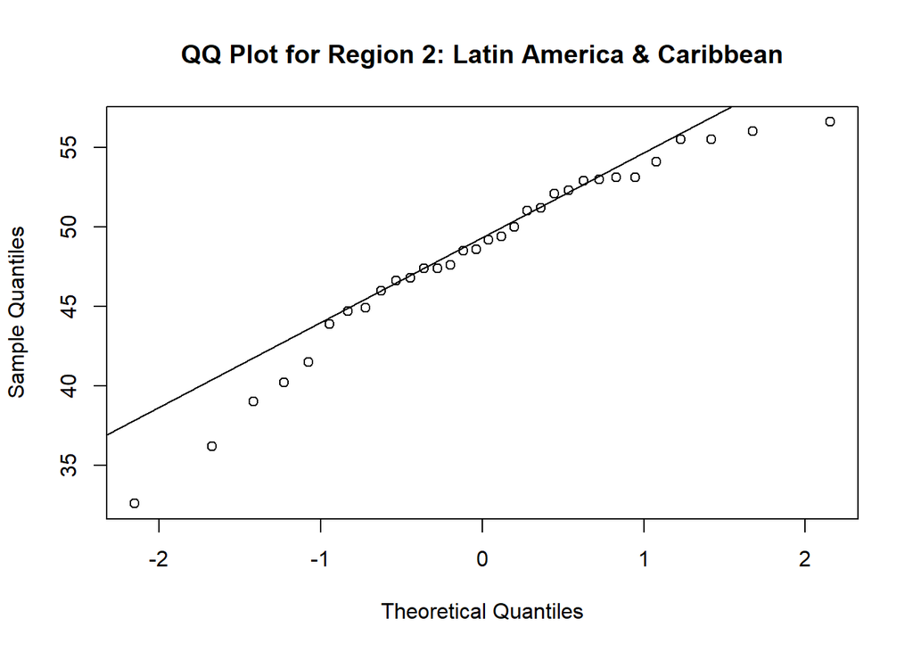

```r
qqnorm(episub2$EPI, main = "QQ Plot for Region 2: Latin America & Caribbean")
qqline(episub2$EPI)
```

**Question2** 2. Fit linear models as follows: 2.1. Choose a subset of 5 variables (excluding EPI) and using the formula EPI~VAR1+VAR2+VAR3+ VAR4+VAR5, fit a linear model and identify which variable most significantly influences EPI. Plot that variable with another and overlay the fitted line. 2.2. Repeat the previous model with a subset of 1 region and in 1-2 sentences explain which model is a better fit and why you think that is the case.

```r
linear_model <- lm(EPI ~ ECO + BDH + SPI + CHA + GTI, data = epi)
summary(linear_model)
```

```
##
## Call:
## lm(formula = EPI ~ ECO + BDH + SPI + CHA + GTI, data = epi)
##
## Residuals:
##     Min      1Q  Median      3Q     Max
## -7.7805 -2.7886 -0.2832  2.6925 10.3481
##
## Coefficients:
##              Estimate Std. Error t value Pr(>|t|)
## (Intercept)  1.910599   1.177261   1.623    0.106
## ECO          0.854533   0.059725  14.308  < 2e-16 ***
## BDH         -0.222041   0.046279  -4.798 3.46e-06 ***
## SPI         -0.009048   0.017368  -0.521    0.603
## CHA          0.025065   0.016334   1.535    0.127
## GTI          0.288216   0.031166   9.248  < 2e-16 ***
## ---
## Signif. codes:  0 '***' 0.001 '**' 0.01 '*' 0.05 '.' 0.1 ' ' 1
##
## Residual standard error: 3.574 on 172 degrees of freedom
##   (2 observations deleted due to missingness)
## Multiple R-squared:  0.9077, Adjusted R-squared:  0.905
## F-statistic: 338.2 on 5 and 172 DF,  p-value: < 2.2e-16
```

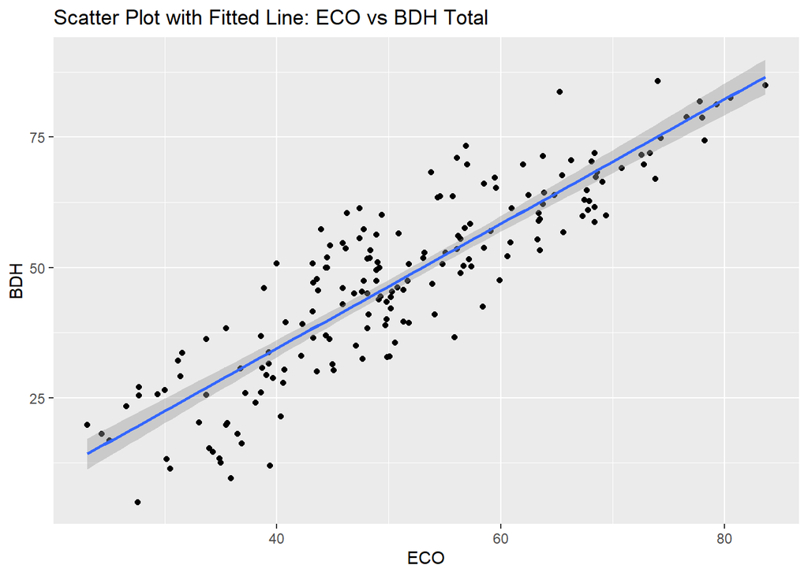

```r
ggplot(epi, aes(x = ECO, y = BDH)) +  geom_point() +  stat_smooth(method = "lm")+ ggtitle("Scatter Plot with Fitted Line: ECO vs BDH Total") +  xlab("ECO") +  ylab("BDH")
```

```r
linear_model_region2 <- lm(EPI ~ ECO + BDH + SPI + CHA + GTI, data = episub2)
summary(linear_model_region2)
```

```
##
## Call:
## lm(formula = EPI ~ ECO + BDH + SPI + CHA + GTI, data = episub2)
##
## Residuals:
##     Min      1Q  Median      3Q     Max
## -6.1805 -2.6554  0.2636  2.1794  7.5220
##
## Coefficients:
##             Estimate Std. Error t value Pr(>|t|)
## (Intercept)  8.64058    6.60492   1.308 0.202253
## ECO          0.87189    0.21001   4.152 0.000314 ***
## BDH         -0.18614    0.14458  -1.288 0.209262
## SPI         -0.08873    0.06231  -1.424 0.166387
## CHA          0.02381    0.07684   0.310 0.759156
## GTI          0.14912    0.11079   1.346 0.189930
## ---
## Signif. codes:  0 '***' 0.001 '**' 0.01 '*' 0.05 '.' 0.1 ' ' 1
##
## Residual standard error: 3.978 on 26 degrees of freedom
## Multiple R-squared:  0.6095, Adjusted R-squared:  0.5344
## F-statistic: 8.117 on 5 and 26 DF,  p-value: 0.0001011
```

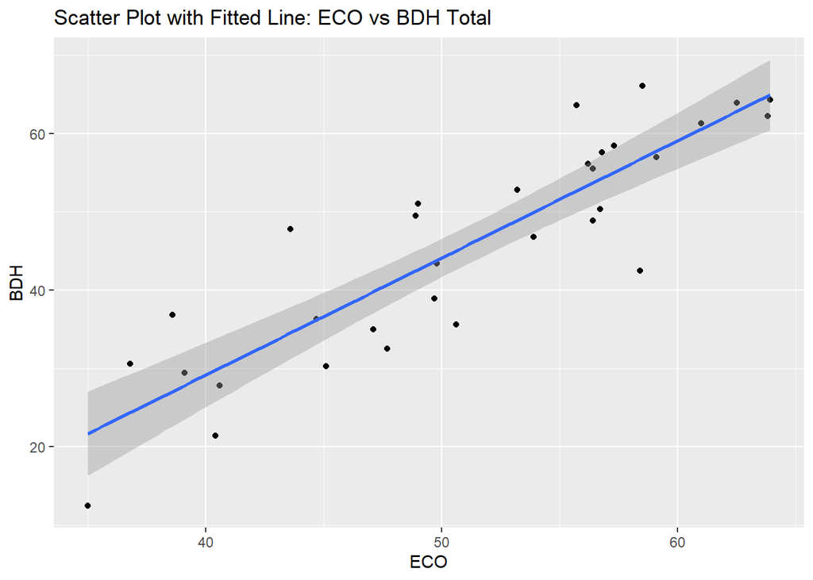

```r
ggplot(episub2, aes(x = ECO, y = BDH)) +  geom_point() +  stat_smooth(method = "lm")+ ggtitle("Scatter Plot with Fitted Line: ECO vs BDH Total") +  xlab("ECO") +  ylab("BDH")
```

*2.2 Since Residual standard error is less and R-squared is more for linear_model taken by considering all data points compared to the model generated by taking the value of “Latin America & Caribbean” only, the first model is better model.*

**Question 3** 3. Train 2 kNN models using ”region” as the class label as follows: 3.1. Choose a subset of 5 variables and filter the subset by region keeping 3 regions out of 8 (representing 3 classes), then train a kNN model to predict the region based on these variables. Evaluate the model using a contingency matrix and calculate the accuracy of correct classifications. 3.2. Repeat the previous model with the same variables for another set of 3 other regions and evaluate. In 1-2 sentences explain which model is better and why you think that is the case.

```r
region_filter1 <- epi[epi$region %in% c("Greater Middle East", "Eastern Europe", "Asia-Pacific"), ]

subset1 <- region_filter1[, c("ECO", "BDH", "SPI", "CHA", "GTI", "region")]
subset1 <- na.omit(subset1)

set.seed(123)
n = nrow(subset1)
train_index1 <- sample(n, n * 0.7)
train_epi1 <- subset1[train_index1, ]
test_epi1 <- subset1[-train_index1, ]

train_x1 <- train_epi1[, -6]
train_y1 <- train_epi1[, 6]
test_x1 <- test_epi1[, -6]
test_y1 <- test_epi1[, 6]

KNNpred <- knn(train = train_x1, test = test_x1, cl = train_y1, k = 3)


contingency_table1 <- table(Predicted = KNNpred, Actual = test_y1, dnn=list('predicted','actual'))
print(contingency_table1)
```

```
##                      actual
## predicted             Asia-Pacific Eastern Europe Greater Middle East
##   Asia-Pacific                   2              0                   2
##   Eastern Europe                 1              5                   1
##   Greater Middle East            1              2                   4
```

```r
sum(diag(contingency_table1))/length(test_y1)
```

```
## [1] 0.6111111
```

```r
accuracy <- c()
ks <- seq(1,20,1)

for (k in ks) {

  KNNpred <- knn(train = train_x1, test = test_x1, cl = train_y1, k = k)
  cm = as.matrix(table(Actual=KNNpred, Predicted = test_y1, dnn=list('predicted','actual')))

  accuracy <- c(accuracy,sum(diag(cm))/length(test_y1))

}
print(length(accuracy))
```

```
## [1] 20
```

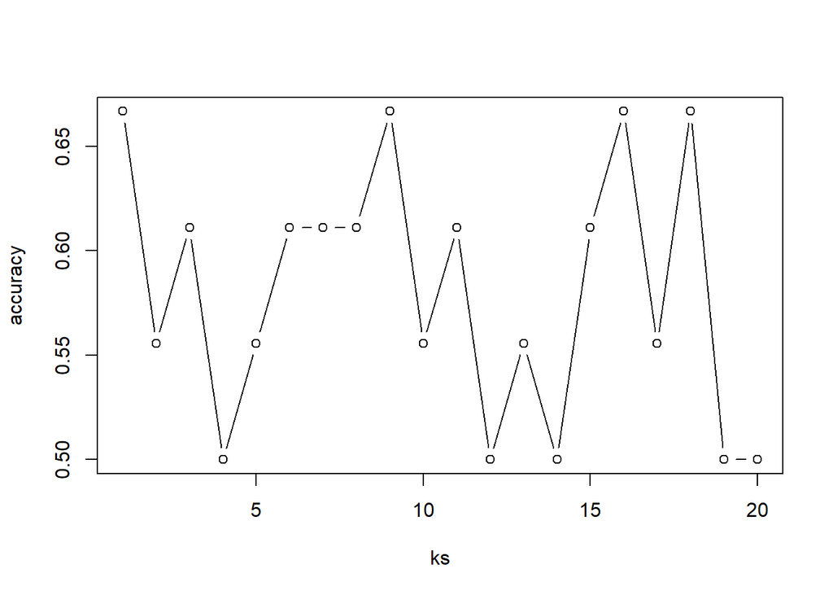

```r
plot(ks,accuracy,type = "b")
```

```r
region_filter2 <- epi[epi$region %in% c("Sub-Saharan Africa", "Global West", "Latin America & Caribbean"), ]

# Select the same 5 variables and the 'region' column
subset2 <- region_filter2[, c("ECO", "BDH", "SPI", "CHA", "GTI", "region")]
subset2 <- na.omit(subset2)

# Split into training and testing sets
set.seed(123)
n = nrow(subset2)
train_index2 <- sample(n, n * 0.7)
train_epi2 <- subset2[train_index2, ]
test_epi2 <- subset2[-train_index2, ]

# Prepare the features and labels for training and testing
train_x2 <- train_epi2[, -6]  # Features
train_y2 <- train_epi2[, 6]   # Labels (regions)
test_x2 <- test_epi2[, -6]    # Features for testing
test_y2 <- test_epi2[, 6]     # Labels for testing

# Train the second kNN model
KNNpred2 <- knn(train = train_x2, test = test_x2, cl = train_y2, k = 1)

# Create a contingency table (confusion matrix)
contingency_table2 <- table(Predicted = KNNpred2, Actual = test_y2)
print(contingency_table2)
```

```
##                            Actual
## Predicted                   Global West Latin America & Caribbean
##   Global West                         4                         1
##   Latin America & Caribbean           0                        11
##   Sub-Saharan Africa                  0                         1
##                            Actual
## Predicted                   Sub-Saharan Africa
##   Global West                                1
##   Latin America & Caribbean                  1
##   Sub-Saharan Africa                        11
```

```r
# Convert the contingency table to a matrix and calculate accuracy
accuracy2 <- sum(diag(as.matrix(contingency_table2))) / length(test_y2)
print(paste("Accuracy for Model 2:", accuracy2))
```

```
## [1] "Accuracy for Model 2: 0.866666666666667"
```

```r
accuracy2 <- c()
ks2 <- seq(1,20,1)

for (k in ks) {

  KNNpred2 <- knn(train = train_x2, test = test_x2, cl = train_y2, k = k)
  cm2 = as.matrix(table(Actual=KNNpred2, Predicted = test_y2, dnn=list('predicted','actual')))

  accuracy2 <- c(accuracy2,sum(diag(cm2))/length(test_y2))

}
print(length(accuracy2))
```

```
## [1] 20
```

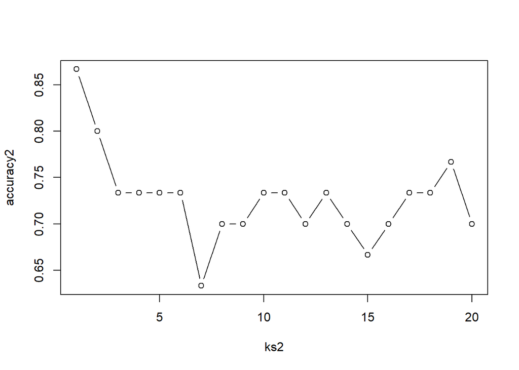

```r
plot(ks2,accuracy2,type = "b")
```

*Since the Accuracy of model 2 is better, the model 2 is a better fit.*

**Question 4** Using the EPI results dataset to perform the following: 1. Fit a k-means model for a subset of 5 variables for 2 different groups of regions (3 each) 1.1. Compare the performance of the models using their within cluster sum of squares. 1.2. In a loop fit kmeansmodels for both subsets using multiple values of k. Plot WCSS across k values. In 1-2 sentences explain which model is better and why you think that is the case.

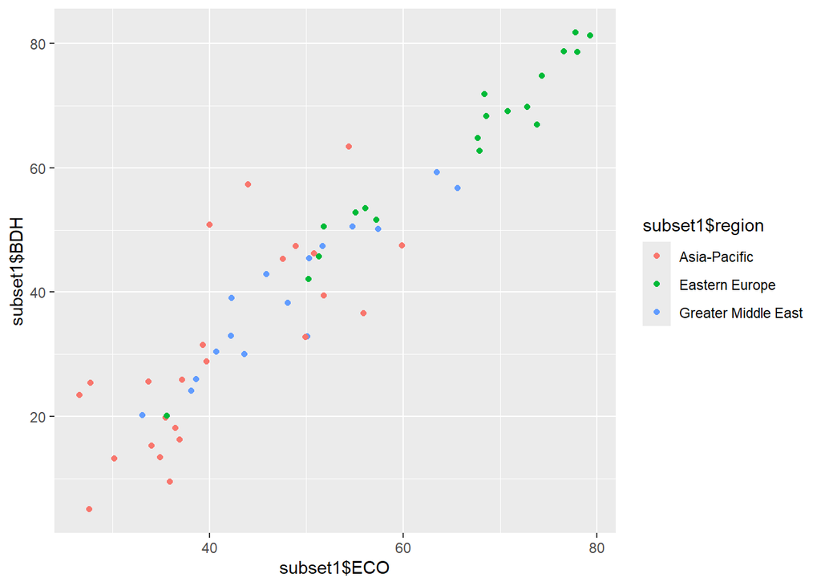

```r
ggplot(subset1, aes(x = subset1$ECO, y = subset1$BDH, colour = subset1$region)) +  geom_point()
```

```r
set.seed(123)
km <- kmeans(subset1[,-6], centers = 3)
km$tot.withinss
```

```
## [1] 54794.12
```

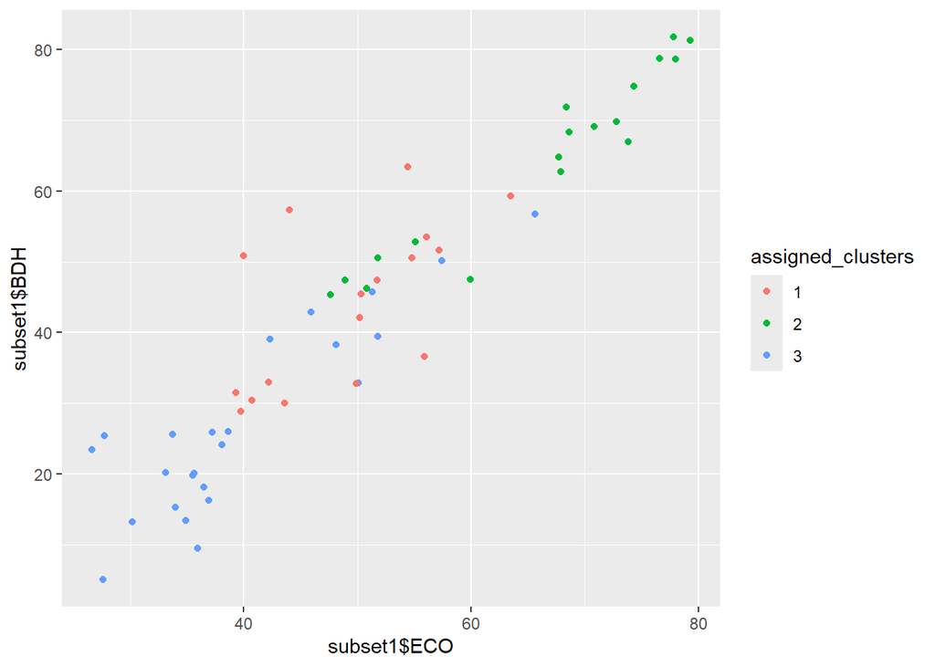

```r
assigned_clusters <- as.factor(km$cluster)

ggplot(subset1, aes(x = subset1$ECO, y = subset1$BDH, colour = assigned_clusters)) +  geom_point()
```

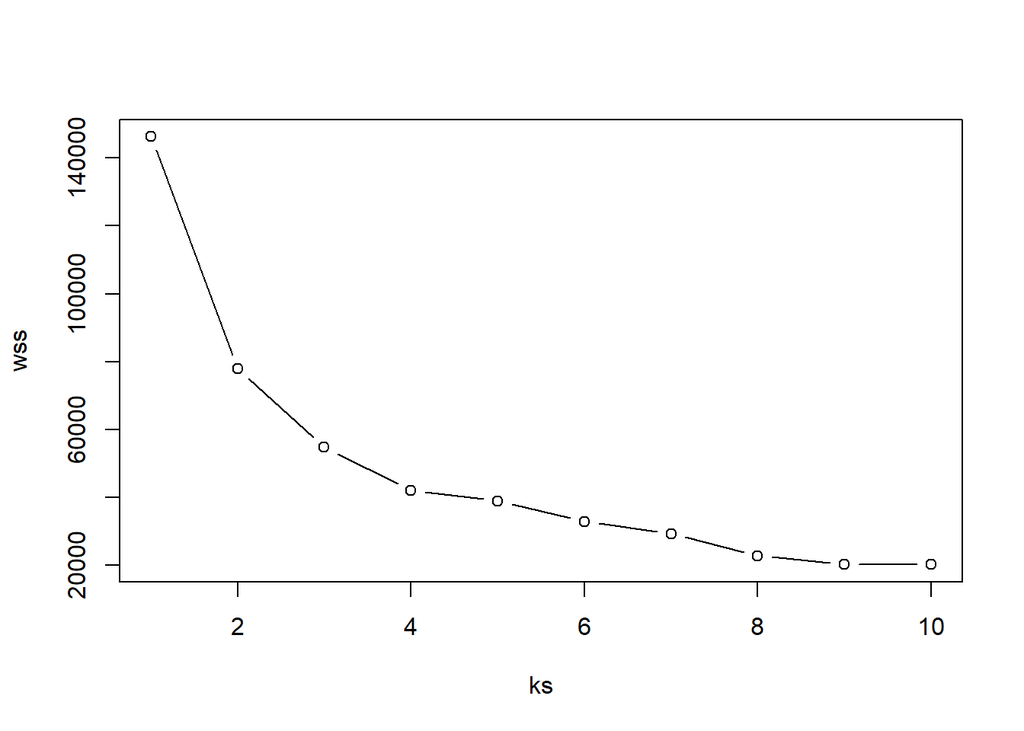

```r
wss <- c()
ks<-1:10
for (k in ks) {
  km <- kmeans(subset1[,-6], centers = k)
  wss <- c(wss,km$tot.withinss)
}
plot(ks,wss,type = "b")
```

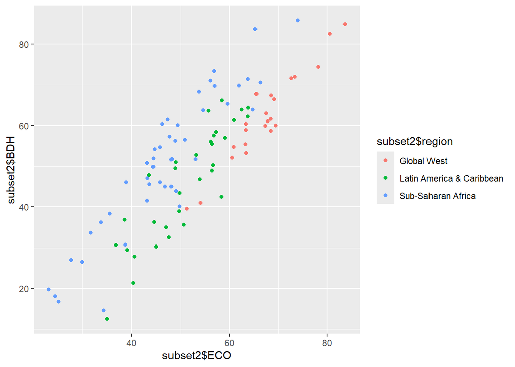

```r
ggplot(subset2, aes(x = subset2$ECO, y = subset2$BDH, colour = subset2$region)) +  geom_point()
```

```r
set.seed(123)

km2 <- kmeans(subset2[,-6], centers = 3)
km2$tot.withinss
```

```
## [1] 71327.2
```

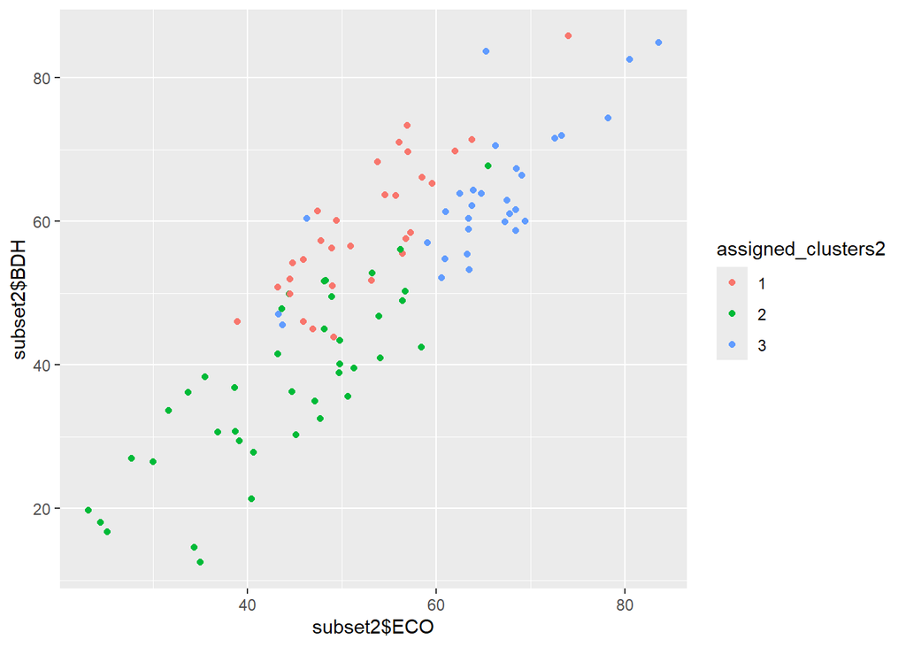

```r
assigned_clusters2 <- as.factor(km2$cluster)

ggplot(subset2, aes(x = subset2$ECO, y = subset2$BDH, colour = assigned_clusters2)) +  geom_point()
```

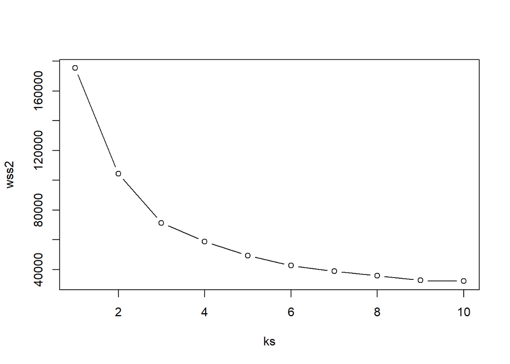

```r
wss2 <- c()

ks<-1:10
for (k in ks) {
  km2 <- kmeans(subset2[,-6], centers = k)
  wss2 <- c(wss2,km2$tot.withinss)
}
plot(ks,wss2,type = "b")
```

* Model 1 is a better fit, since the value at the elbow of the graph (at value of k=4 for both the graph) the value of wss is less for the first model*